# Environmental indicator analysis-Tilefish

##### Bottom T analysis

The following figures compare in-situ bottom temperature from the study-fleet data set to the Study fleet and Observer tilefish catch data.

- Note here temperatures are averaged across all depths > 50 for each month.

```r
bt.cpue = sfob.env %>% filter(year > 2006 & depth > 50 & cpue_hr > 0 & cpue_hr < 15) %>%
  group_by(year,month) %>%
  summarise(mean_dpth = mean(depth),
            mean_bt = mean(bottomt),
            min_bt = min(bottomt),
            max_bt = max(bottomt),
            sd_bt = sd(bottomt),
            mean_tri = mean(tri),
            mean_sed = mean(sed),
            mean_cpue = mean(cpue_hr))

# See what months have data
sort(unique(bt.cpue$month))
```

```
##  [1]  1  2  3  4  5  6  7  8  9 10 11 12
```

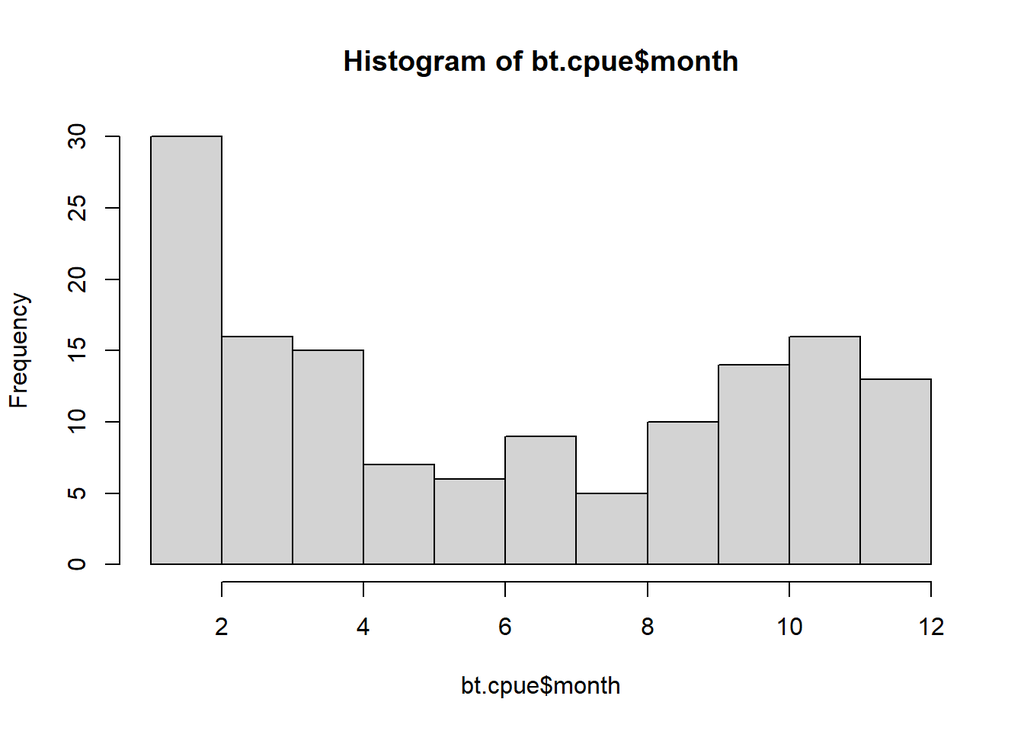

```r
hist(bt.cpue$month)
```

**Bottom temp regression and correlation - Observer insitu bt - No Lag**

```r
lm_bt<-lm(mean_bt ~ mean_cpue, data=bt.cpue)
summary(lm_bt)
```

```
##
## Call:
## lm(formula = mean_bt ~ mean_cpue, data = bt.cpue)
##
## Residuals:
##     Min      1Q  Median      3Q     Max
## -5.6026 -1.2897  0.1934  1.1972  3.0474
##
## Coefficients:
##             Estimate Std. Error t value Pr(>|t|)
## (Intercept) 11.48160    0.30244  37.963   <2e-16 ***
## mean_cpue    0.09561    0.07684   1.244    0.216
## ---
## Signif. codes:  0 '***' 0.001 '**' 0.01 '*' 0.05 '.' 0.1 ' ' 1
##
## Residual standard error: 1.71 on 121 degrees of freedom
##   (18 observations deleted due to missingness)
## Multiple R-squared:  0.01263,    Adjusted R-squared:  0.004474
## F-statistic: 1.548 on 1 and 121 DF,  p-value: 0.2158
```

```r
bt.cpue = bt.cpue %>%
  mutate(season = case_when(month %in% c(1,2,3) ~ 'winter',
                            month %in% c(4,5,6) ~ 'spring',
                            month %in% c(7,8,9) ~ 'summer',
                            month %in% c(10,11,12) ~ 'fall'))

cor.test(bt.cpue$mean_cpue, bt.cpue$mean_bt, method=c("pearson"))
```

```
##
##  Pearson's product-moment correlation
##
## data:  bt.cpue$mean_cpue and bt.cpue$mean_bt
## t = 1.2443, df = 121, p-value = 0.2158
## alternative hypothesis: true correlation is not equal to 0
## 95 percent confidence interval:
##  -0.0659437  0.2837900
## sample estimates:
##       cor
## 0.1124029
```

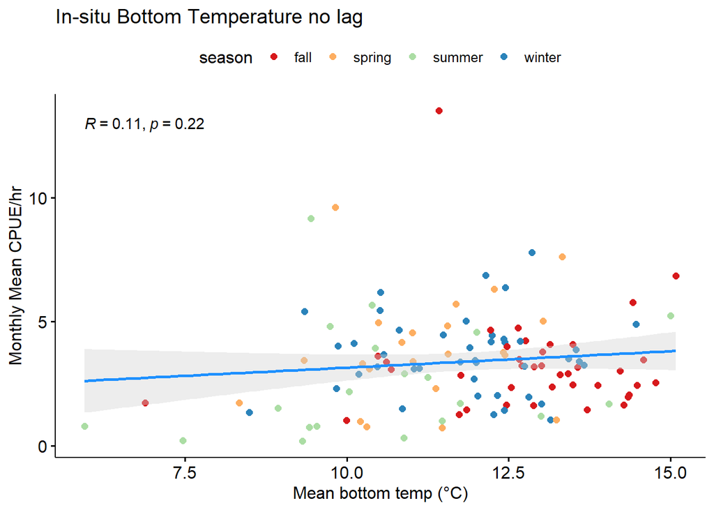

```r
# all seasons, color coded by season
ggscatter(bt.cpue, x = "mean_bt", y = "mean_cpue",
          add = "reg.line", conf.int = TRUE,
          color ="season", palette = c("Spectral"),
          cor.coef = TRUE, cor.coeff.args = list(method="pearson"),
          add.params=list(color="dodgerblue", fill="lightgray"),
          xlab = "Mean bottom temp (°C)", ylab = "Monthly Mean CPUE/hr",
          title = "In-situ Bottom Temperature no lag")
```

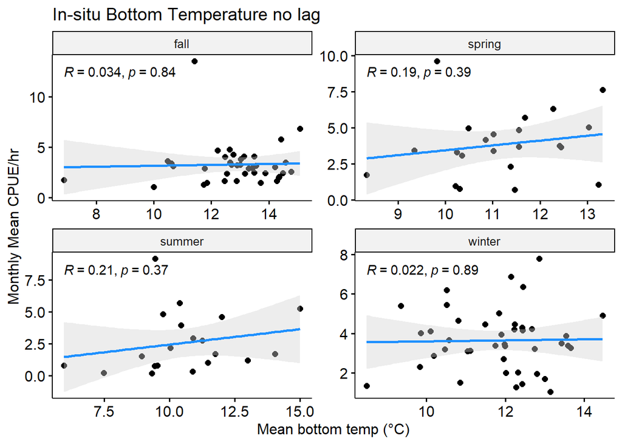

```r
# plot by season
bt.cpue %>% group_by(year, season) %>%
 ggscatter(x = "mean_bt", y = "mean_cpue",
          add = "reg.line", conf.int = TRUE,
          cor.coef = TRUE, cor.coeff.args = list(method="pearson"),
          add.params=list(color="dodgerblue", fill="lightgray"),
          xlab = "Mean bottom temp (°C)", ylab = "Monthly Mean CPUE/hr",
          title = "In-situ Bottom Temperature no lag")+
  facet_wrap(~season, scales = 'free')
```

**Regression for sf/ob CPUE and GLORYS bt - No Lag**

```r
#filter by year, depth, cpue, mean_temp_c
glorys.bt = sfob.env %>% filter(mean_temp_c > 0, depth > 50 & cpue_hr > 0 & cpue_hr < 15) %>%
  group_by(year,month) %>%
  summarise(mean_tri = mean(tri),
            mean_sed = mean(sed),
            mean_cpue = mean(cpue_hr),
            mean_glorysbt = mean(mean_temp_c))

# Correlation and plot
lm_glorys<-lm(mean_glorysbt ~ mean_cpue, data=glorys.bt)
summary(lm_glorys)
```

```
##
## Call:
## lm(formula = mean_glorysbt ~ mean_cpue, data = glorys.bt)
##
## Residuals:
##     Min      1Q  Median      3Q     Max
## -3.7460 -0.7505 -0.0279  0.8958  3.0998
##
## Coefficients:
##              Estimate Std. Error t value Pr(>|t|)
## (Intercept) 12.876150   0.268521  47.952   <2e-16 ***
## mean_cpue    0.002953   0.052070   0.057    0.955
## ---
## Signif. codes:  0 '***' 0.001 '**' 0.01 '*' 0.05 '.' 0.1 ' ' 1
##
## Residual standard error: 1.274 on 62 degrees of freedom
## Multiple R-squared:  5.186e-05,  Adjusted R-squared:  -0.01608
## F-statistic: 0.003216 on 1 and 62 DF,  p-value: 0.955
```

```r
glorys.bt = glorys.bt %>%
  mutate(season = case_when(month %in% c(1,2,3) ~ 'winter',
                            month %in% c(4,5,6) ~ 'spring',
                            month %in% c(7,8,9) ~ 'summer',
                            month %in% c(10,11,12) ~ 'fall'))

cor.test(glorys.bt$mean_cpue, glorys.bt$mean_glorysbt, method=c("pearson"))
```

```
##
##  Pearson's product-moment correlation
##
## data:  glorys.bt$mean_cpue and glorys.bt$mean_glorysbt
## t = 0.056706, df = 62, p-value = 0.955
## alternative hypothesis: true correlation is not equal to 0
## 95 percent confidence interval:
##  -0.2390310  0.2525637
## sample estimates:
##         cor
## 0.007201456
```

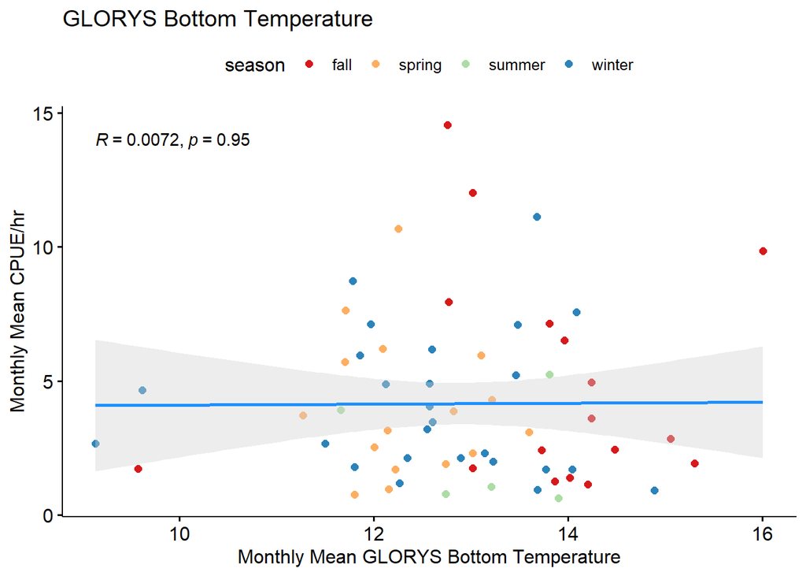

```r
ggscatter(glorys.bt, x = "mean_glorysbt", y = "mean_cpue",
          add = "reg.line", conf.int = TRUE,
          color ="season", palette = c("Spectral"),
          cor.coef = TRUE, cor.coeff.args = list(method="pearson"),
          add.params=list(color="dodgerblue", fill="lightgray"),
          xlab = "Monthly Mean GLORYS Bottom Temperature", ylab = "Monthly Mean CPUE/hr",
          title = "GLORYS Bottom Temperature")
```

##### Salinity

- 55 meters (relevant to larvae, recruits)
- 110 meters (relevant recruits, juveniles)
- 220 meters (relevant to juveniles, adults)

##### Salinity analysis

```r
sal <- read.csv(here::here("data/study_fleet_obs_env.csv"))

#filter depth and remove CPUE outliers
sal = sal %>% filter(year > 1997 & depth > 50 & cpue_hr > 0 & cpue_hr < 15) %>%
  group_by(year,month) %>%
  summarise(mean_sal = mean(btm_sal),
            mean_tri = mean(tri),
            mean_sed = mean(sed),
            mean_cpue = mean(cpue_hr)) %>%
   tidyr::drop_na()

#designate season
sal = sal %>%
  mutate(season = case_when(month %in% c(1,2,3) ~ 'winter',
                            month %in% c(4,5,6) ~ 'spring',
                            month %in% c(7,8,9) ~ 'summer',
                            month %in% c(10,11,12) ~ 'fall'))
```

**Regression and correlation CPUE and salinity - No Lag**

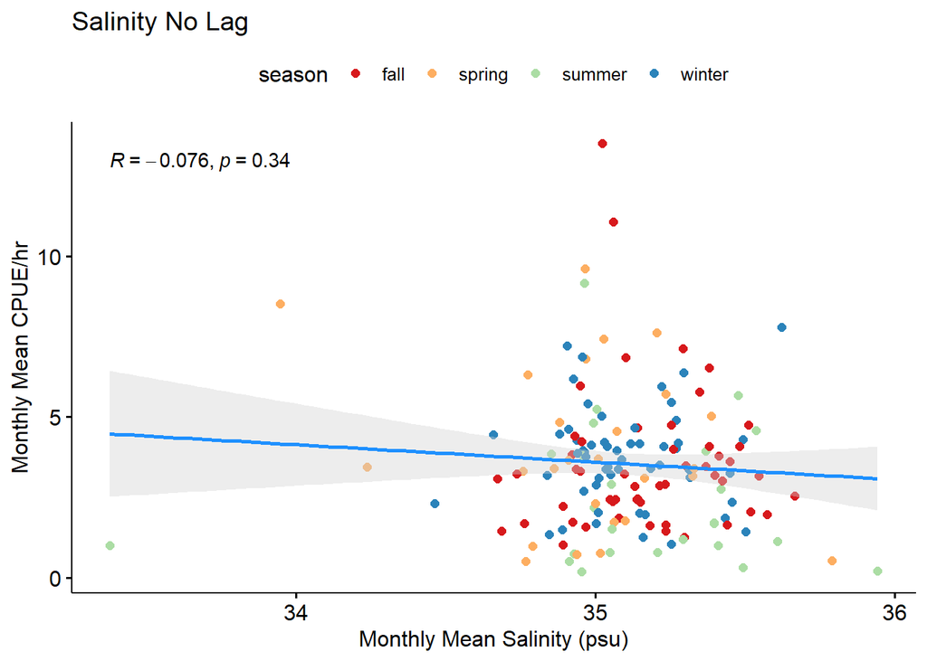

```r
# all seasons, color coded by season
ggscatter(sal, x = "mean_sal", y = "mean_cpue",
          add = "reg.line", conf.int = TRUE,
          color ="season", palette = c("Spectral"),
          cor.coef = TRUE, cor.coeff.args = list(method="pearson"),
          add.params=list(color="dodgerblue", fill="lightgray"),
          xlab = "Monthly Mean Salinity (psu)", ylab = "Monthly Mean CPUE/hr",
          title = "Salinity No Lag")
```

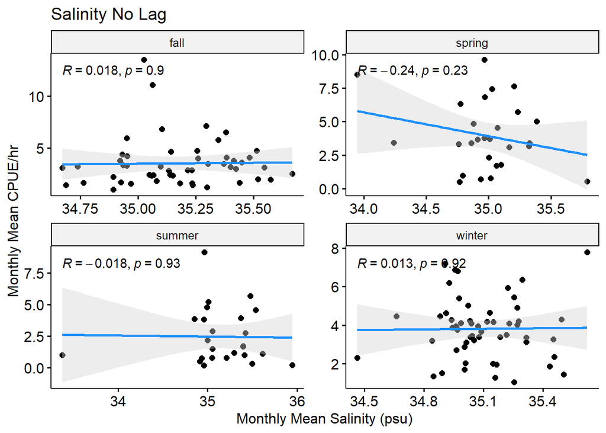

```r
# plot by season
sal %>% group_by(year, season) %>%
 ggscatter(x = "mean_sal", y = "mean_cpue",
          add = "reg.line", conf.int = TRUE,
          cor.coef = TRUE, cor.coeff.args = list(method="pearson"),
          add.params=list(color="dodgerblue", fill="lightgray"),
          xlab = "Monthly Mean Salinity (psu)", ylab = "Monthly Mean CPUE/hr",
          title = "Salinity No Lag")+
  facet_wrap(~season, scales = 'free')
```

#### Currents

Cross-shelf processes may influence the retention or displacement of tilefish during early life history stages. These are explored below.

##### Shelf water volume

Shelf water volume: A measure of the volume of water bounded inshore of the shelf-slope front. In this analysis, shelf water is defined as all water having salinity <34 psu. The position of the shelf-slope front varies inter-annually with the higher shelf water values indicating the front being pushed further towards the shelf break.

high shv: front pushed towards sbf low shv: front pushed inshore (more slope water on shelf)

Hypothesis: Higher recruitment success correlated with years of higher shelf water volume in spring/summer. These months months may be particularly important as that is when spawning is occurring and the position of the sbf may influence the position of larvae (away from spawning grounds).

Additional variables in this dataset are shelf water temperature and salinity which may also be indicative of habitat conditions.

```r
# Shelf water volume
shlfvol <- read.csv(here::here('data/shelf_water_volume/ShelfWaterVolume_BSB_update.csv'))

# wrangling date info, converting doy to date and month
yrs <- as.vector(nrow(shlfvol))
shlfvol$Year <- as.character(shlfvol$Year)
for (i in 1:nrow(shlfvol)){
  yrs[i] <- strsplit(shlfvol$Year, ".", fixed = TRUE)[[i]][1]
}
shlfvol$year <- yrs
shlfvol <- shlfvol %>% mutate(date_= as.Date(Year.Day-1,
                                             origin=paste0(year, "-01-01")),
                              month= strftime(date_, "%m"),
                              day=strftime(date_,"%d"),
                              year = as.integer(year),
                              month = as.numeric(month))
```

**Shelf water volume with Study fleet/Observer data**

```r
# Create shw vol by month w mean V, T, S
shlfvol = shlfvol %>%
  filter(year > 1997) %>%
  group_by(year,month) %>%
  summarise(mean_t = mean(ShW.T),
            mean_s = mean(ShW.S),
            mean_v = mean(ShW.Vol))

#filter sfob.env
shlfvol.sfob = sfob.env %>% filter(depth > 50, cpue_hr > 0, cpue_hr<15) %>%
  group_by(year,month) %>%
  summarise(mean_dpth = mean(depth),
            mean_bt = mean(bottomt),
            mean_cpue = mean(cpue_hr),
            mean_tri = mean(tri),
            mean_sed = mean(sed))

# Join with sf/ob data
df.shlfvol.sfob = dplyr::full_join(shlfvol.sfob, shlfvol, by = join_by(year, month)) %>%
  dplyr::select(year, month, mean_cpue, mean_tri, mean_sed, mean_t, mean_s, mean_v) %>%
  tidyr::drop_na()

#See what months have data
sort(unique(df.shlfvol.sfob$month))
```

```
## [1]  2  3  4  5  7  8  9 10 11
```

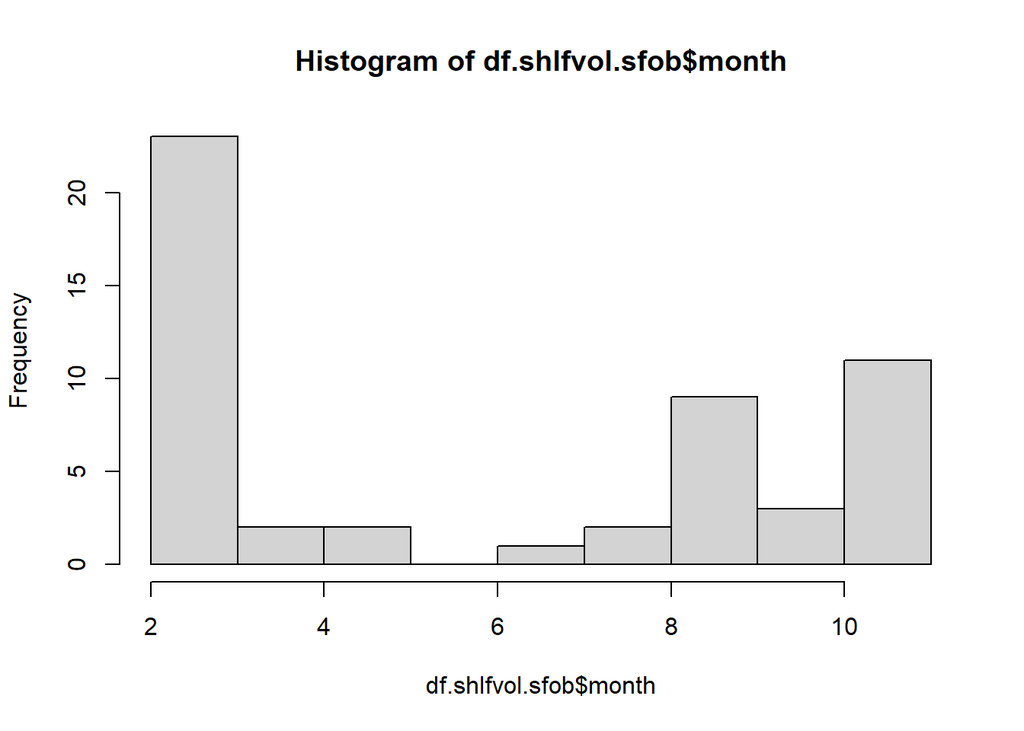

```r
hist(df.shlfvol.sfob$month)
```

**Regressions and correlation between sf/ob CPUE and shelf water volume/temp/salinity - No Lag**

```r
#shelf water volum

lm_shlf<-lm(mean_v ~ mean_cpue, data=df.shlfvol.sfob)
summary(lm_shlf)
```

```
##
## Call:
## lm(formula = mean_v ~ mean_cpue, data = df.shlfvol.sfob)
##
## Residuals:
##     Min      1Q  Median      3Q     Max
## -1541.4  -392.4  -103.3   550.7  1796.3
##
## Coefficients:
##             Estimate Std. Error t value Pr(>|t|)
## (Intercept)  3401.65     233.03  14.598   <2e-16 ***
## mean_cpue      69.45      59.10   1.175    0.245
## ---
## Signif. codes:  0 '***' 0.001 '**' 0.01 '*' 0.05 '.' 0.1 ' ' 1
##
## Residual standard error: 806.4 on 51 degrees of freedom
## Multiple R-squared:  0.02636,    Adjusted R-squared:  0.007267
## F-statistic: 1.381 on 1 and 51 DF,  p-value: 0.2454
```

```r
df.shlfvol.sfob = df.shlfvol.sfob %>%
  mutate(season = case_when(month %in% c(1,2,3) ~ 'winter',
                            month %in% c(4,5,6) ~ 'spring',
                            month %in% c(7,8,9) ~ 'summer',
                            month %in% c(10,11,12) ~ 'fall'))

cor.test(df.shlfvol.sfob$mean_cpue, df.shlfvol.sfob$mean_v, method=c("pearson"))
```

```
##
##  Pearson's product-moment correlation
##
## data:  df.shlfvol.sfob$mean_cpue and df.shlfvol.sfob$mean_v
## t = 1.175, df = 51, p-value = 0.2454
## alternative hypothesis: true correlation is not equal to 0
## 95 percent confidence interval:
##  -0.1128956  0.4144586
## sample estimates:
##       cor
## 0.1623524
```

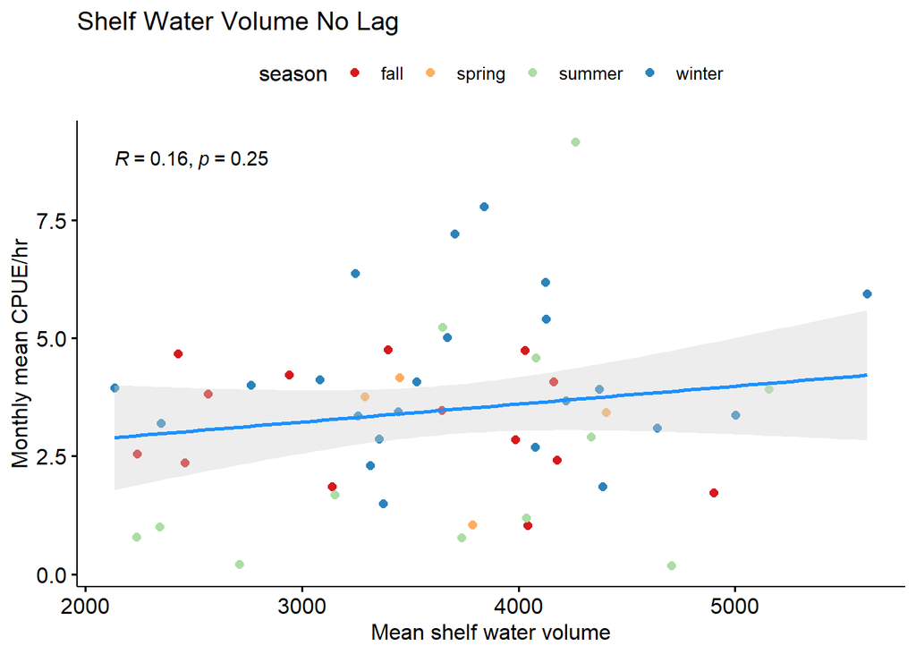

```r
#all months, color coded by season
ggscatter(df.shlfvol.sfob, x = "mean_v", y = "mean_cpue",
          add = "reg.line", conf.int = TRUE,
          color="season", palette="Spectral",
          cor.coef = TRUE, cor.coeff.args = list(method="pearson"),
          add.params=list(color="dodgerblue", fill="lightgray"),
          xlab = "Mean shelf water volume", ylab = "Monthly mean CPUE/hr", title="Shelf Water Volume No Lag")
```

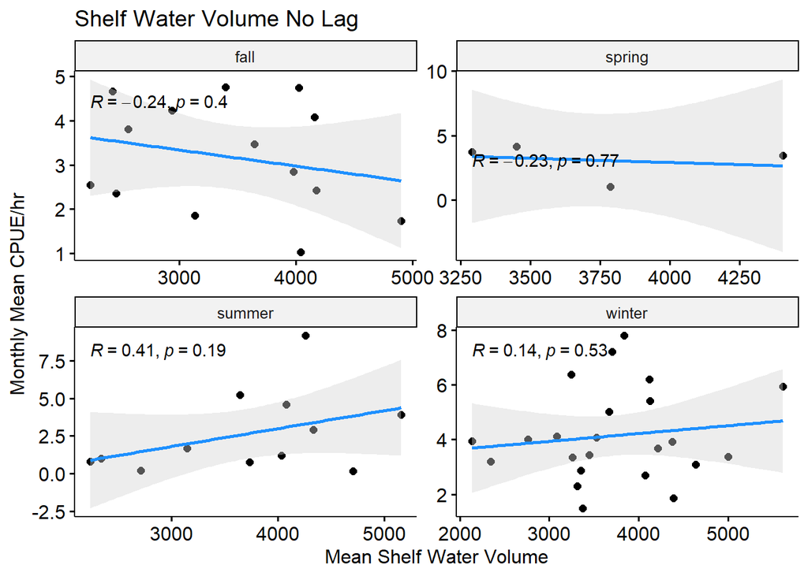

```r
# by season
df.shlfvol.sfob %>% group_by(year, season) %>%
 ggscatter(x = "mean_v", y = "mean_cpue",
          add = "reg.line", conf.int = TRUE,
          cor.coef = TRUE, cor.coeff.args = list(method="pearson"),
          add.params=list(color="dodgerblue", fill="lightgray"),
          xlab = "Mean Shelf Water Volume", ylab = "Monthly Mean CPUE/hr",
          title = "Shelf Water Volume No Lag")+
  facet_wrap(~season, scales = 'free')
```

```r
##############################################################

# shelf water temperature
lm_shlf_t<-lm(mean_t ~ mean_cpue, data=df.shlfvol.sfob)
summary(lm_shlf_t)
```

```
##
## Call:
## lm(formula = mean_t ~ mean_cpue, data = df.shlfvol.sfob)
##
## Residuals:
##    Min     1Q Median     3Q    Max
## -6.358 -4.379 -1.026  4.167  9.039
##
## Coefficients:
##             Estimate Std. Error t value Pr(>|t|)
## (Intercept)  14.4736     1.3266  10.911 6.08e-15 ***
## mean_cpue    -1.0080     0.3365  -2.996  0.00422 **
## ---
## Signif. codes:  0 '***' 0.001 '**' 0.01 '*' 0.05 '.' 0.1 ' ' 1
##
## Residual standard error: 4.591 on 51 degrees of freedom
## Multiple R-squared:  0.1497, Adjusted R-squared:  0.133
## F-statistic: 8.976 on 1 and 51 DF,  p-value: 0.004216
```

```r
cor.test(df.shlfvol.sfob$mean_cpue, df.shlfvol.sfob$mean_t, method=c("pearson"))
```

```
##
##  Pearson's product-moment correlation
##
## data:  df.shlfvol.sfob$mean_cpue and df.shlfvol.sfob$mean_t
## t = -2.996, df = 51, p-value = 0.004216
## alternative hypothesis: true correlation is not equal to 0
## 95 percent confidence interval:
##  -0.5949396 -0.1301732
## sample estimates:
##        cor
## -0.3868555
```

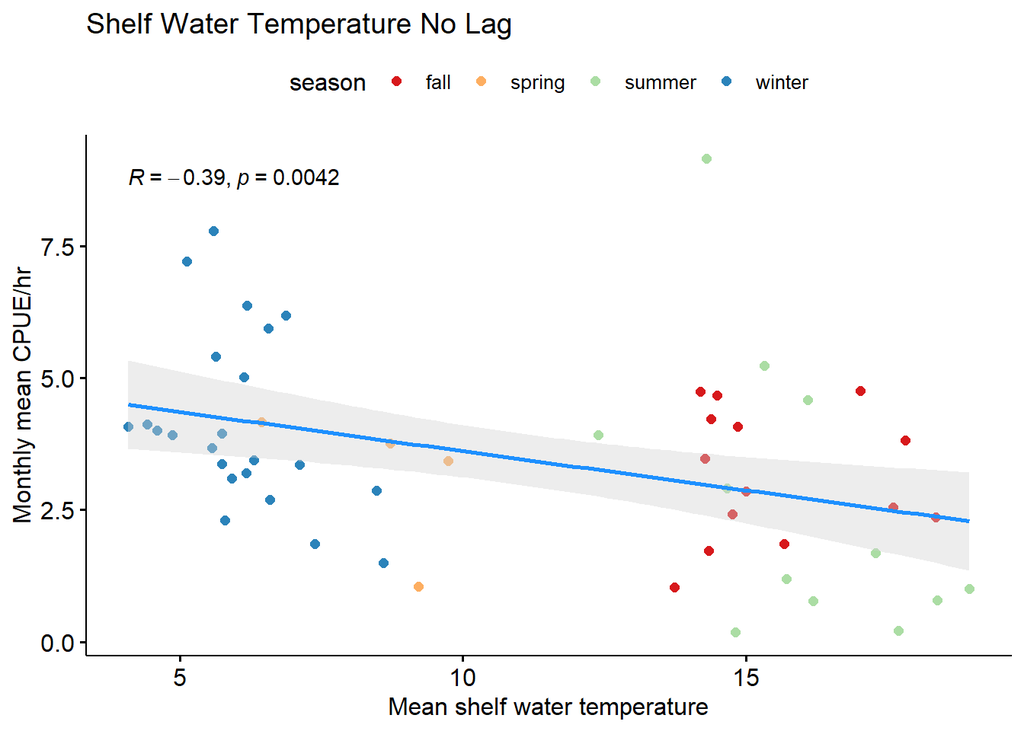

```r
#all months, color coded by season
ggscatter(df.shlfvol.sfob, x = "mean_t", y = "mean_cpue",
          add = "reg.line", conf.int = TRUE,
          color="season", palette="Spectral",
          cor.coef = TRUE, cor.coeff.args = list(method="pearson"),
          add.params=list(color="dodgerblue", fill="lightgray"),
          xlab = "Mean shelf water temperature", ylab = "Monthly mean CPUE/hr", title="Shelf Water Temperature No Lag")
```

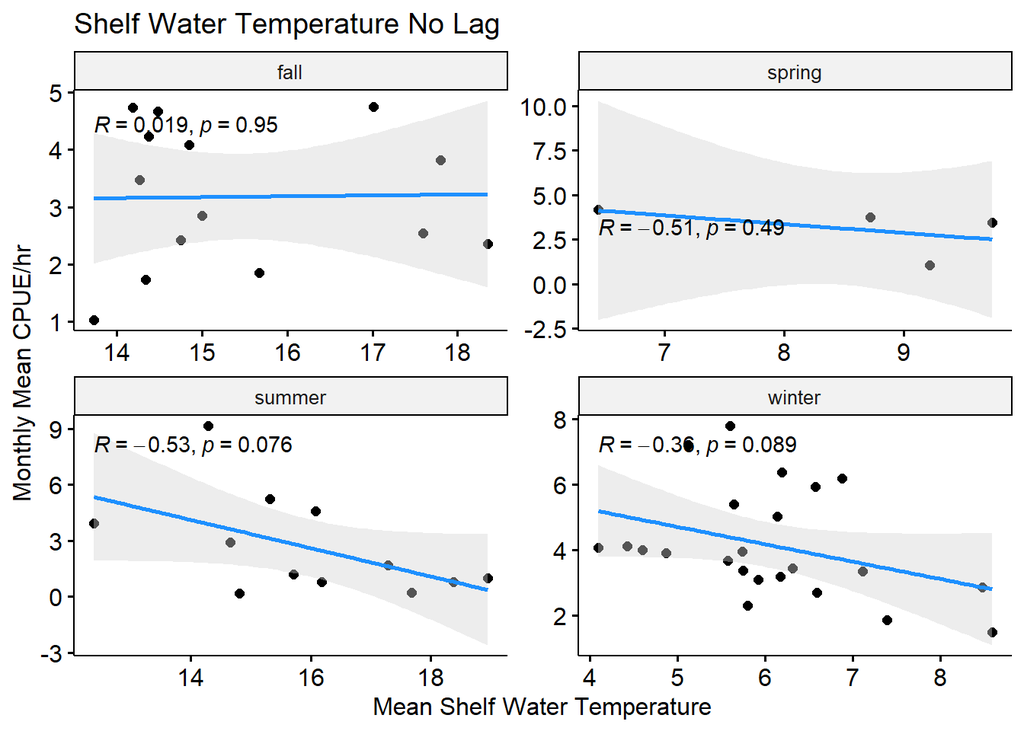

```r
#by season
df.shlfvol.sfob %>% group_by(year, season) %>%
 ggscatter(x = "mean_t", y = "mean_cpue",
          add = "reg.line", conf.int = TRUE,
          cor.coef = TRUE, cor.coeff.args = list(method="pearson"),
          add.params=list(color="dodgerblue", fill="lightgray"),
          xlab = "Mean Shelf Water Temperature", ylab = "Monthly Mean CPUE/hr",
          title = "Shelf Water Temperature No Lag")+
  facet_wrap(~season, scales = 'free')
```

```r
##########################################################################

# shelf water salinity
lm_shlf_s<-lm(mean_s ~ mean_cpue, data=df.shlfvol.sfob)
summary(lm_shlf_s)
```

```
##
## Call:
## lm(formula = mean_s ~ mean_cpue, data = df.shlfvol.sfob)
##
## Residuals:
##     Min      1Q  Median      3Q     Max
## -0.5784 -0.1686 -0.0186  0.1215  0.5615
##
## Coefficients:
##               Estimate Std. Error t value Pr(>|t|)
## (Intercept) 32.9086526  0.0708229 464.661   <2e-16 ***
## mean_cpue   -0.0000467  0.0179629  -0.003    0.998
## ---
## Signif. codes:  0 '***' 0.001 '**' 0.01 '*' 0.05 '.' 0.1 ' ' 1
##
## Residual standard error: 0.2451 on 51 degrees of freedom
## Multiple R-squared:  1.325e-07,  Adjusted R-squared:  -0.01961
## F-statistic: 6.759e-06 on 1 and 51 DF,  p-value: 0.9979
```

```r
cor.test(df.shlfvol.sfob$mean_cpue, df.shlfvol.sfob$mean_s, method=c("pearson"))
```

```
##
##  Pearson's product-moment correlation
##
## data:  df.shlfvol.sfob$mean_cpue and df.shlfvol.sfob$mean_s
## t = -0.0025998, df = 51, p-value = 0.9979
## alternative hypothesis: true correlation is not equal to 0
## 95 percent confidence interval:
##  -0.2706312  0.2699563
## sample estimates:
##           cor
## -0.0003640386
```

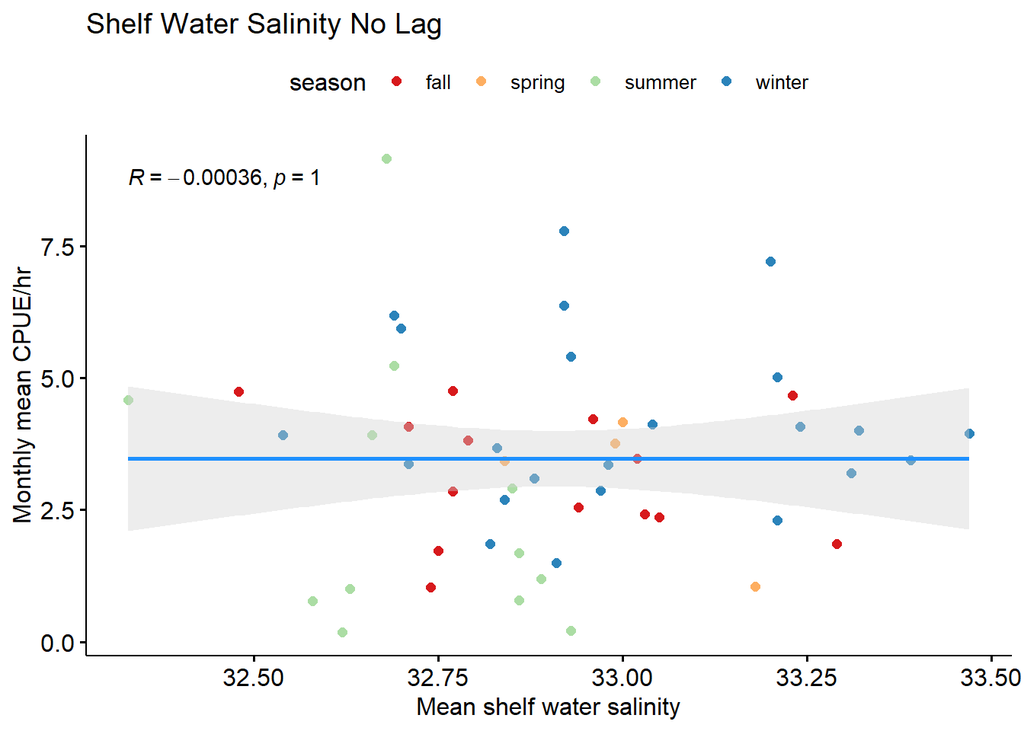

```r
ggscatter(df.shlfvol.sfob, x = "mean_s", y = "mean_cpue",
          add = "reg.line", conf.int = TRUE,
          color="season", palette="Spectral",
          cor.coef = TRUE, cor.coeff.args = list(method="pearson"),
          add.params=list(color="dodgerblue", fill="lightgray"),
          xlab = "Mean shelf water salinity", ylab = "Monthly mean CPUE/hr", title="Shelf Water Salinity No Lag")
```

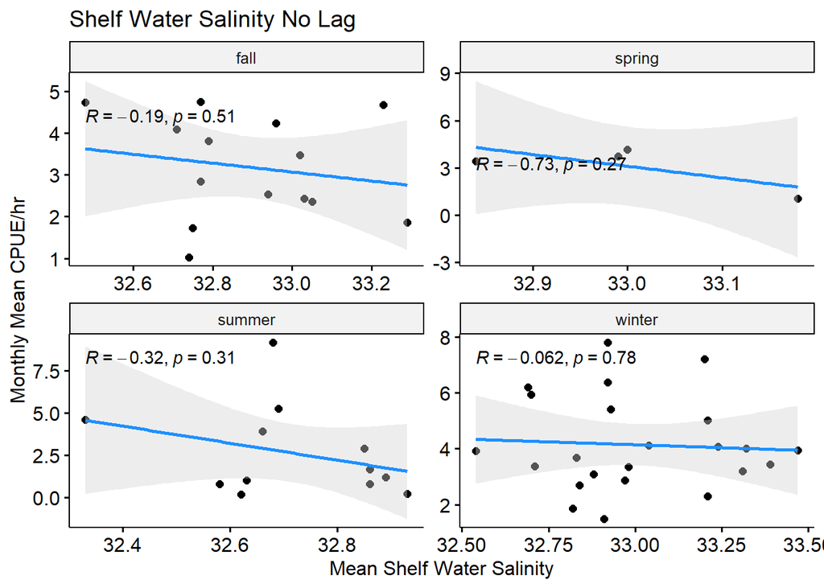

```r
# by season
df.shlfvol.sfob %>% group_by(year, season) %>%
 ggscatter(x = "mean_s", y = "mean_cpue",
          add = "reg.line", conf.int = TRUE,
          cor.coef = TRUE, cor.coeff.args = list(method="pearson"),
          add.params=list(color="dodgerblue", fill="lightgray"),
          xlab = "Mean Shelf Water Salinity", ylab = "Monthly Mean CPUE/hr",
          title = "Shelf Water Salinity No Lag")+
  facet_wrap(~season, scales = 'free')
```

##### Gulf-stream index

Gulf stream index was calculated based on method presented by Pérez-Hernández and Joyce (2014). The gulf stream index (GSI) is a measure of the degrees latitude above the average Gulf Stream position based on ocean temperature at 200m (15 C) depth between 55W to 75W.

Positive values indicate a the mean position of the GS is more Northernly, whereas negative values indicate a more Southernly position.

**GSI/recruitment year lags - comparison to Nesslage ea 2023**

```r
gsi.m <- read.csv(here::here('data/gulf_stream_index/mm_gsi_1954_2022_chen.csv'))
df <- dplyr::full_join(recruit, gsi.m %>%
                   group_by(year) %>%
                   filter(month %in% c(3:8)) %>%
                   summarise(m.gsi = mean(GSI),
                             sd.gsi = sd(GSI),
                             max.gsi = max(GSI),
                             min.gsi = min(GSI)),
                 by = join_by(year)) %>%
  mutate(mean_gsi_lag1 = lag(m.gsi,1),
         mean_gsi_lag2 = lag(m.gsi,2),
         mean_gsi_lag3 = lag(m.gsi,3),
         mean_gsi_lag6 = lag(m.gsi,6),
         mean_gsi_lag7 = lag(m.gsi,7)) %>%
  mutate(pos = ifelse(m.gsi > 0, 'Northerly', 'Southerly'),
         n.pos = ifelse(m.gsi > 0, 1, 0))
gsi_df <- df[-c(51:69),]
gsi_df <- gsi_df[-c(13),] # removes recruitment outlier

## No lag
lm_rec_gsi<-lm(m.gsi ~ recruit_est, data=gsi_df)
summary(lm_rec_gsi)
```

```
##
## Call:
## lm(formula = m.gsi ~ recruit_est, data = gsi_df)
##
## Residuals:
##      Min       1Q   Median       3Q      Max
## -1.36934 -0.53872 -0.06646  0.55505  1.29036
##
## Coefficients:
##              Estimate Std. Error t value Pr(>|t|)
## (Intercept) 2.188e-01  2.565e-01   0.853    0.398
## recruit_est 3.419e-08  1.642e-07   0.208    0.836
##
## Residual standard error: 0.7216 on 47 degrees of freedom
## Multiple R-squared:  0.0009216,  Adjusted R-squared:  -0.02034
## F-statistic: 0.04336 on 1 and 47 DF,  p-value: 0.836
```

```r
cor.test(gsi_df$recruit_est, gsi_df$m.gsi, method=c("pearson"))
```

```
##
##  Pearson's product-moment correlation
##
## data:  gsi_df$recruit_est and gsi_df$m.gsi
## t = 0.20822, df = 47, p-value = 0.836
## alternative hypothesis: true correlation is not equal to 0
## 95 percent confidence interval:
##  -0.2529980  0.3089178
## sample estimates:
##        cor
## 0.03035838
```

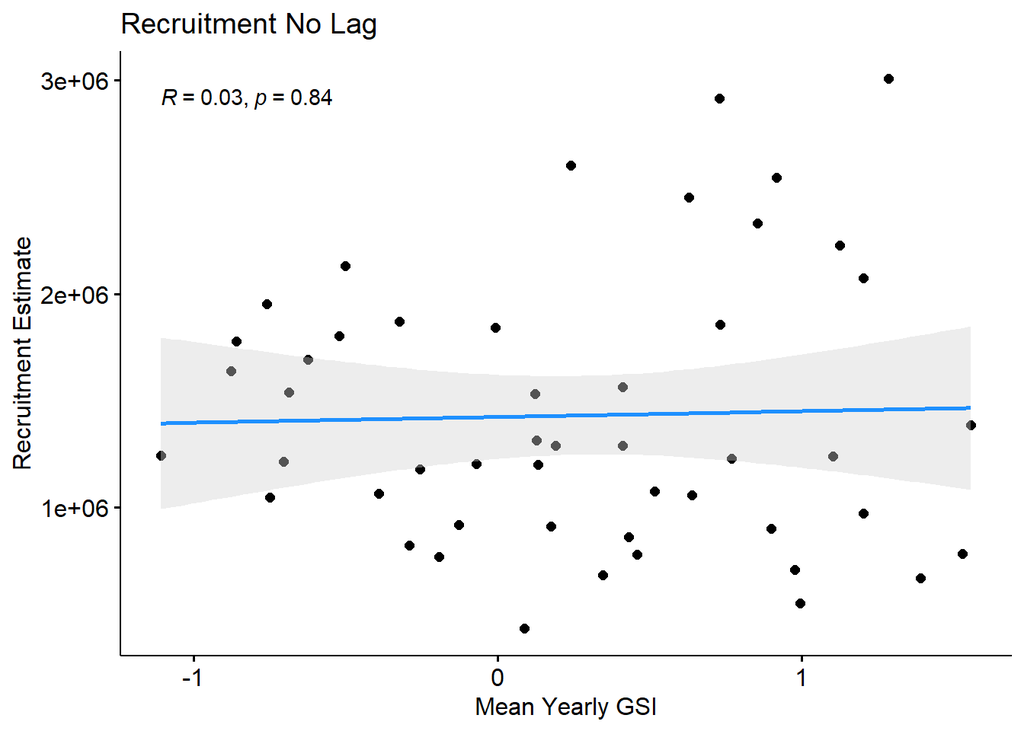

```r
ggscatter(gsi_df, x = "m.gsi", y = "recruit_est",
          add = "reg.line", conf.int = TRUE,
          cor.coef = TRUE, cor.coeff.args = list(method="pearson"),
          add.params=list(color="dodgerblue", fill="lightgray"),
          xlab = "Mean Yearly GSI", ylab = "Recruitment Estimate",
          title = "Recruitment No Lag")
```

```r
## 1 year lag
lm_rec_gsi1<-lm(mean_gsi_lag1 ~ recruit_est, data=gsi_df)
summary(lm_rec_gsi1)
```

```
##
## Call:
## lm(formula = mean_gsi_lag1 ~ recruit_est, data = gsi_df)
##
## Residuals:
##      Min       1Q   Median       3Q      Max
## -1.41118 -0.56366  0.00751  0.53388  1.33505
##
## Coefficients:
##               Estimate Std. Error t value Pr(>|t|)
## (Intercept)  5.520e-01  2.506e-01   2.203   0.0327 *
## recruit_est -2.067e-07  1.598e-07  -1.294   0.2023
## ---
## Signif. codes:  0 '***' 0.001 '**' 0.01 '*' 0.05 '.' 0.1 ' ' 1
##
## Residual standard error: 0.7016 on 46 degrees of freedom
##   (1 observation deleted due to missingness)
## Multiple R-squared:  0.0351, Adjusted R-squared:  0.01412
## F-statistic: 1.673 on 1 and 46 DF,  p-value: 0.2023
```

```r
cor.test(gsi_df$recruit_est, gsi_df$mean_gsi_lag1, method=c("pearson"))
```

```
##
##  Pearson's product-moment correlation
##
## data:  gsi_df$recruit_est and gsi_df$mean_gsi_lag1
## t = -1.2935, df = 46, p-value = 0.2023
## alternative hypothesis: true correlation is not equal to 0
## 95 percent confidence interval:
##  -0.4476486  0.1022342
## sample estimates:
##        cor
## -0.1873425
```

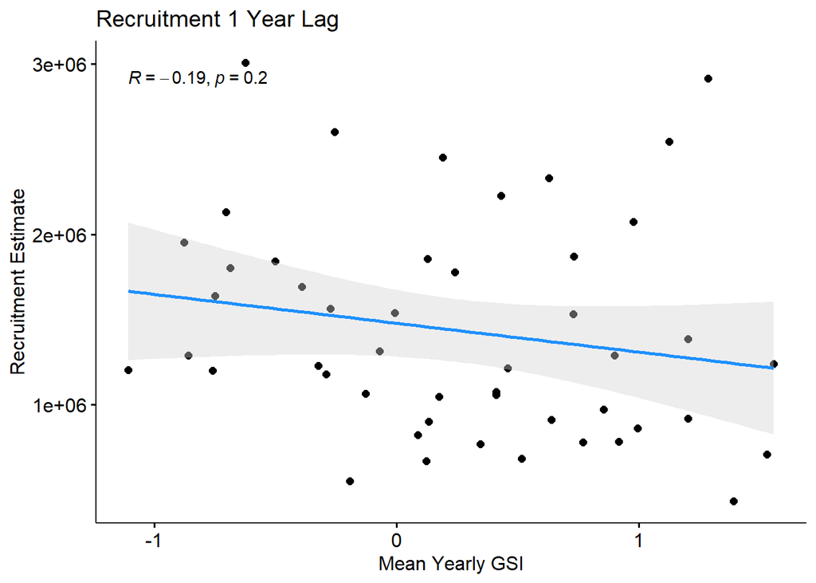

```r
ggscatter(gsi_df, x = "mean_gsi_lag1", y = "recruit_est",
          add = "reg.line", conf.int = TRUE,
          cor.coef = TRUE, cor.coeff.args = list(method="pearson"),
          add.params=list(color="dodgerblue", fill="lightgray"),
          xlab = "Mean Yearly GSI", ylab = "Recruitment Estimate",
          title = "Recruitment 1 Year Lag")
```

```r
## 2 year lag
lm_rec_gsi2<-lm(recruit_est ~ mean_gsi_lag2, data=gsi_df)
summary(lm_rec_gsi2)
```

```
##
## Call:
## lm(formula = recruit_est ~ mean_gsi_lag2, data = gsi_df)
##
## Residuals:
##      Min       1Q   Median       3Q      Max
## -1027099  -484736  -132370   331238  1458567
##
## Coefficients:
##               Estimate Std. Error t value Pr(>|t|)
## (Intercept)    1479881      99031  14.944   <2e-16 ***
## mean_gsi_lag2  -175043     138650  -1.262    0.213
## ---
## Signif. codes:  0 '***' 0.001 '**' 0.01 '*' 0.05 '.' 0.1 ' ' 1
##
## Residual standard error: 642300 on 45 degrees of freedom
##   (2 observations deleted due to missingness)
## Multiple R-squared:  0.03421,    Adjusted R-squared:  0.01275
## F-statistic: 1.594 on 1 and 45 DF,  p-value: 0.2133
```

```r
cor.test(gsi_df$recruit_est, gsi_df$mean_gsi_lag2, method=c("pearson"))
```

```
##
##  Pearson's product-moment correlation
##
## data:  gsi_df$recruit_est and gsi_df$mean_gsi_lag2
## t = -1.2625, df = 45, p-value = 0.2133
## alternative hypothesis: true correlation is not equal to 0
## 95 percent confidence interval:
##  -0.4483090  0.1079472
## sample estimates:
##       cor
## -0.184953
```

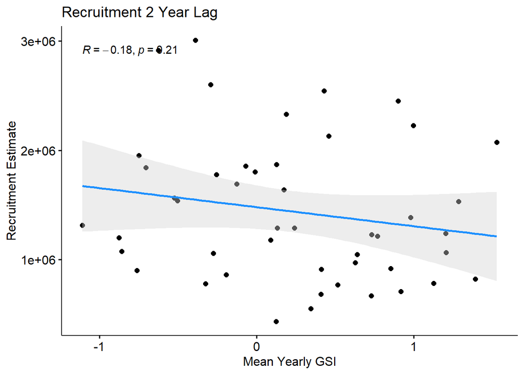

```r
ggscatter(gsi_df, x = "mean_gsi_lag2", y = "recruit_est",
          add = "reg.line", conf.int = TRUE,
          cor.coef = TRUE, cor.coeff.args = list(method="pearson"),
          add.params=list(color="dodgerblue", fill="lightgray"),
          xlab = "Mean Yearly GSI", ylab = "Recruitment Estimate",
          title = "Recruitment 2 Year Lag")
```

```r
## 3 year lag
lm_rec_gsi3<-lm(mean_gsi_lag3 ~ recruit_est, data=gsi_df)
summary(lm_rec_gsi3)
```

```
##
## Call:
## lm(formula = mean_gsi_lag3 ~ recruit_est, data = gsi_df)
##
## Residuals:
##      Min       1Q   Median       3Q      Max
## -1.25846 -0.51294  0.02686  0.46400  1.32597
##
## Coefficients:
##               Estimate Std. Error t value Pr(>|t|)
## (Intercept)  3.524e-01  2.492e-01   1.414    0.164
## recruit_est -1.088e-07  1.577e-07  -0.690    0.494
##
## Residual standard error: 0.6912 on 44 degrees of freedom
##   (3 observations deleted due to missingness)
## Multiple R-squared:  0.01069,    Adjusted R-squared:  -0.01179
## F-statistic: 0.4756 on 1 and 44 DF,  p-value: 0.494
```

```r
cor.test(gsi_df$recruit_est, gsi_df$mean_gsi_lag3, method=c("pearson"))
```

```
##
##  Pearson's product-moment correlation
##
## data:  gsi_df$recruit_est and gsi_df$mean_gsi_lag3
## t = -0.68965, df = 44, p-value = 0.494
## alternative hypothesis: true correlation is not equal to 0
## 95 percent confidence interval:
##  -0.3822346  0.1926708
## sample estimates:
##        cor
## -0.1034113
```

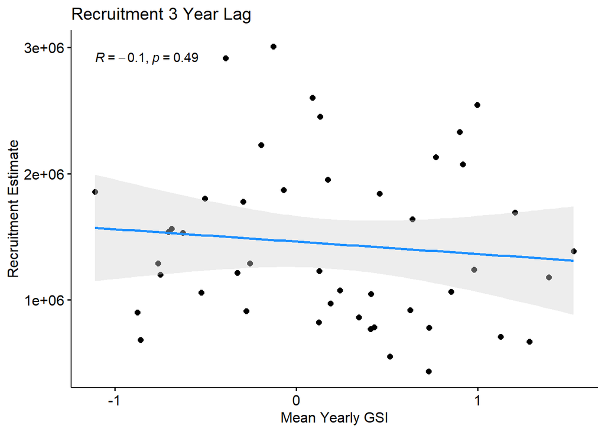

```r
ggscatter(gsi_df, x = "mean_gsi_lag3", y = "recruit_est",
          add = "reg.line", conf.int = TRUE,
          cor.coef = TRUE, cor.coeff.args = list(method="pearson"),
          add.params=list(color="dodgerblue", fill="lightgray"),
          xlab = "Mean Yearly GSI", ylab = "Recruitment Estimate",
          title = "Recruitment 3 Year Lag")
```

```r
## 6 year lag
lm_rec_gsi6<-lm(mean_gsi_lag6 ~ recruit_est, data=gsi_df)
summary(lm_rec_gsi6)
```

```
##
## Call:
## lm(formula = mean_gsi_lag6 ~ recruit_est, data = gsi_df)
##
## Residuals:
##      Min       1Q   Median       3Q      Max
## -1.23331 -0.49821  0.00945  0.35327  1.30887
##
## Coefficients:
##               Estimate Std. Error t value Pr(>|t|)
## (Intercept) -2.582e-01  2.319e-01  -1.113   0.2721
## recruit_est  2.640e-07  1.474e-07   1.791   0.0807 .
## ---
## Signif. codes:  0 '***' 0.001 '**' 0.01 '*' 0.05 '.' 0.1 ' ' 1
##
## Residual standard error: 0.6391 on 41 degrees of freedom
##   (6 observations deleted due to missingness)
## Multiple R-squared:  0.07255,    Adjusted R-squared:  0.04993
## F-statistic: 3.207 on 1 and 41 DF,  p-value: 0.0807
```

```r
cor.test(gsi_df$recruit_est, gsi_df$mean_gsi_lag6, method=c("pearson"))
```

```
##
##  Pearson's product-moment correlation
##
## data:  gsi_df$recruit_est and gsi_df$mean_gsi_lag6
## t = 1.7909, df = 41, p-value = 0.0807
## alternative hypothesis: true correlation is not equal to 0
## 95 percent confidence interval:
##  -0.03372076  0.52705708
## sample estimates:
##      cor
## 0.269351
```

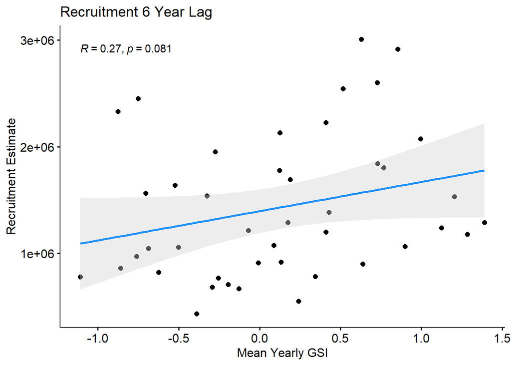

```r
ggscatter(gsi_df, x = "mean_gsi_lag6", y = "recruit_est",
          add = "reg.line", conf.int = TRUE,
          cor.coef = TRUE, cor.coeff.args = list(method="pearson"),
          add.params=list(color="dodgerblue", fill="lightgray"),
          xlab = "Mean Yearly GSI", ylab = "Recruitment Estimate",
          title = "Recruitment 6 Year Lag")
```

```r
## 7 year lag
lm_rec_gsi7<-lm(mean_gsi_lag7 ~ recruit_est, data=gsi_df)
summary(lm_rec_gsi7)
```

```
##
## Call:
## lm(formula = mean_gsi_lag7 ~ recruit_est, data = gsi_df)
##
## Residuals:
##     Min      1Q  Median      3Q     Max
## -1.1718 -0.4398 -0.0091  0.3867  1.3412
##
## Coefficients:
##               Estimate Std. Error t value Pr(>|t|)
## (Intercept) -6.069e-02  2.379e-01  -0.255    0.800
## recruit_est  1.026e-07  1.499e-07   0.684    0.498
##
## Residual standard error: 0.6424 on 40 degrees of freedom
##   (7 observations deleted due to missingness)
## Multiple R-squared:  0.01157,    Adjusted R-squared:  -0.01314
## F-statistic: 0.4684 on 1 and 40 DF,  p-value: 0.4977
```

```r
cor.test(gsi_df$recruit_est, gsi_df$mean_gsi_lag7, method=c("pearson"))
```

```
##
##  Pearson's product-moment correlation
##
## data:  gsi_df$recruit_est and gsi_df$mean_gsi_lag7
## t = 0.68438, df = 40, p-value = 0.4977
## alternative hypothesis: true correlation is not equal to 0
## 95 percent confidence interval:
##  -0.2029868  0.3984837
## sample estimates:
##       cor
## 0.1075818
```

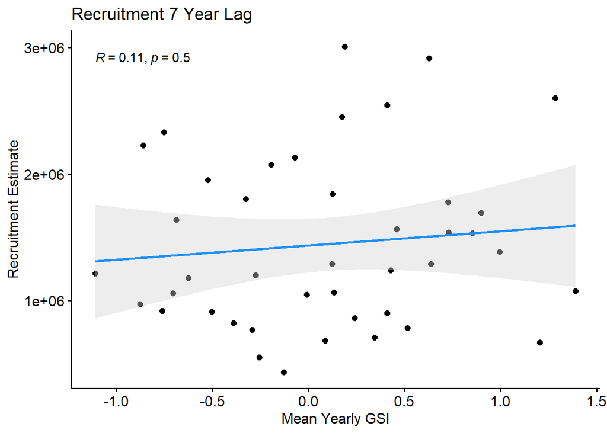

```r
ggscatter(gsi_df, x = "mean_gsi_lag7", y = "recruit_est",
          add = "reg.line", conf.int = TRUE,
          cor.coef = TRUE, cor.coeff.args = list(method="pearson"),
          add.params=list(color="dodgerblue", fill="lightgray"),
          xlab = "Mean Yearly GSI", ylab = "Recruitment Estimate",
          title = "Recruitment 7 Year Lag")
```

**CPUE/Year lags - comparison to Nesslage ea 2023**

```r
sfob_yr<- dplyr::full_join(catch_recruit, gsi.m %>%
                   group_by(year) %>%
                   summarise(m.gsi = mean(GSI),
                             sd.gsi = sd(GSI),
                             max.gsi = max(GSI),
                             min.gsi = min(GSI)),
                 by = join_by(year)) %>%
  mutate(mean_gsi_lag1 = lag(m.gsi,1),
         mean_gsi_lag2 = lag(m.gsi,2),
         mean_gsi_lag3 = lag(m.gsi,3)) %>%
  mutate(pos = ifelse(m.gsi > 0, 'Northerly', 'Southerly'),
         n.pos = ifelse(m.gsi > 0, 1, 0))
gsi_yr <- sfob_yr[-c(20:21,24:69),] #removes years not in study fleet and 2 outliers

## No lag
lm_cpue_gsi<-lm(m.gsi ~ ttl_sum, data=gsi_yr)
summary(lm_cpue_gsi)
```

```
##
## Call:
## lm(formula = m.gsi ~ ttl_sum, data = gsi_yr)
##
## Residuals:
##     Min      1Q  Median      3Q     Max
## -1.1295 -0.5937  0.1162  0.4767  0.9813
##
## Coefficients:
##              Estimate Std. Error t value Pr(>|t|)
## (Intercept) 0.2746646  0.2449066   1.122    0.276
## ttl_sum     0.0001985  0.0001557   1.275    0.218
##
## Residual standard error: 0.6701 on 19 degrees of freedom
## Multiple R-squared:  0.07878,    Adjusted R-squared:  0.0303
## F-statistic: 1.625 on 1 and 19 DF,  p-value: 0.2178
```

```r
cor.test(gsi_yr$ttl_sum, gsi_yr$m.gsi, method=c("pearson"))
```

```
##
##  Pearson's product-moment correlation
##
## data:  gsi_yr$ttl_sum and gsi_yr$m.gsi
## t = 1.2747, df = 19, p-value = 0.2178
## alternative hypothesis: true correlation is not equal to 0
## 95 percent confidence interval:
##  -0.1718200  0.6353842
## sample estimates:
##       cor
## 0.2806859
```

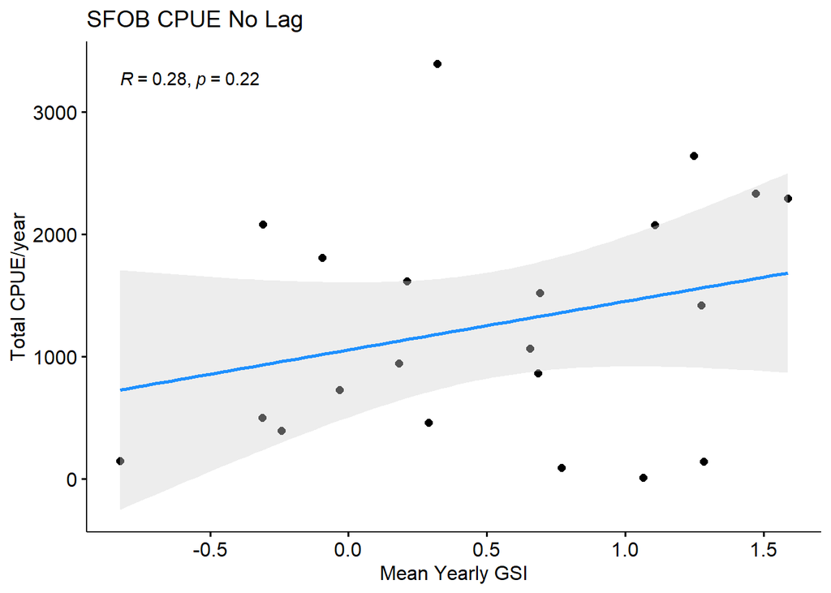

```r
ggscatter(gsi_yr, x = "m.gsi", y = "ttl_sum",
          add = "reg.line", conf.int = TRUE,
          cor.coef = TRUE, cor.coeff.args = list(method="pearson"),
          add.params=list(color="dodgerblue", fill="lightgray"),
          xlab = "Mean Yearly GSI", ylab = "Total CPUE/year",
          title = "SFOB CPUE No Lag")
```

```r
## 1 year lag
lm_cpue_gsi1<-lm(mean_gsi_lag1 ~ ttl_sum, data=gsi_yr)
summary(lm_cpue_gsi1)
```

```
##
## Call:
## lm(formula = mean_gsi_lag1 ~ ttl_sum, data = gsi_yr)
##
## Residuals:
##      Min       1Q   Median       3Q      Max
## -1.39351 -0.43190 -0.09479  0.51141  0.92795
##
## Coefficients:
##              Estimate Std. Error t value Pr(>|t|)
## (Intercept) 0.1119394  0.2355120   0.475   0.6403
## ttl_sum     0.0002818  0.0001465   1.924   0.0703 .
## ---
## Signif. codes:  0 '***' 0.001 '**' 0.01 '*' 0.05 '.' 0.1 ' ' 1
##
## Residual standard error: 0.6198 on 18 degrees of freedom
##   (1 observation deleted due to missingness)
## Multiple R-squared:  0.1706, Adjusted R-squared:  0.1245
## F-statistic: 3.702 on 1 and 18 DF,  p-value: 0.07032
```

```r
cor.test(gsi_yr$ttl_sum, gsi_yr$mean_gsi_lag1, method=c("pearson"))
```

```
##
##  Pearson's product-moment correlation
##
## data:  gsi_yr$ttl_sum and gsi_yr$mean_gsi_lag1
## t = 1.924, df = 18, p-value = 0.07032
## alternative hypothesis: true correlation is not equal to 0
## 95 percent confidence interval:
##  -0.03612372  0.72332456
## sample estimates:
##       cor
## 0.4129991
```

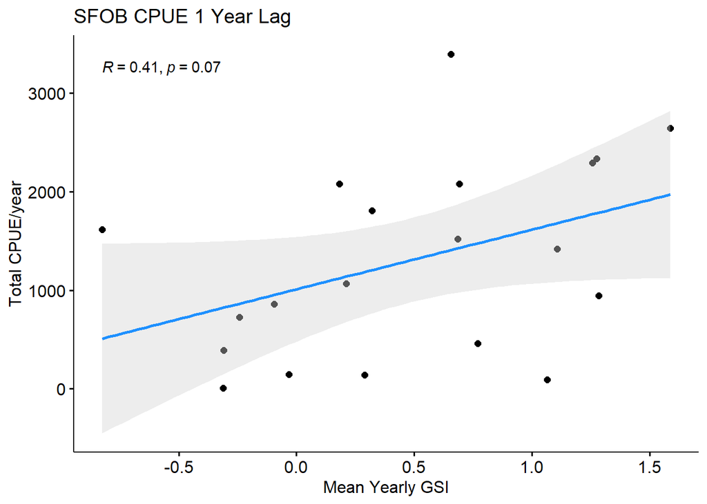

```r
ggscatter(gsi_yr, x = "mean_gsi_lag1", y = "ttl_sum",
          add = "reg.line", conf.int = TRUE,
          cor.coef = TRUE, cor.coeff.args = list(method="pearson"),
          add.params=list(color="dodgerblue", fill="lightgray"),
          xlab = "Mean Yearly GSI", ylab = "Total CPUE/year",
          title = "SFOB CPUE 1 Year Lag")
```

```r
## 2 year lag
lm_cpue_gsi2<-lm(mean_gsi_lag2 ~ ttl_sum, data=gsi_yr)
summary(lm_cpue_gsi2)
```

```
##
## Call:
## lm(formula = mean_gsi_lag2 ~ ttl_sum, data = gsi_yr)
##
## Residuals:
##      Min       1Q   Median       3Q      Max
## -1.14663 -0.43408  0.05566  0.37488  0.91261
##
## Coefficients:
##             Estimate Std. Error t value Pr(>|t|)
## (Intercept) 0.026435   0.230986   0.114   0.9102
## ttl_sum     0.000276   0.000140   1.971   0.0652 .
## ---
## Signif. codes:  0 '***' 0.001 '**' 0.01 '*' 0.05 '.' 0.1 ' ' 1
##
## Residual standard error: 0.5627 on 17 degrees of freedom
##   (2 observations deleted due to missingness)
## Multiple R-squared:  0.186,  Adjusted R-squared:  0.1381
## F-statistic: 3.885 on 1 and 17 DF,  p-value: 0.06523
```

```r
cor.test(gsi_yr$ttl_sum, gsi_yr$mean_gsi_lag2, method=c("pearson"))
```

```
##
##  Pearson's product-moment correlation
##
## data:  gsi_yr$ttl_sum and gsi_yr$mean_gsi_lag2
## t = 1.9709, df = 17, p-value = 0.06523
## alternative hypothesis: true correlation is not equal to 0
## 95 percent confidence interval:
##  -0.02851206  0.74044431
## sample estimates:
##       cor
## 0.4312825
```

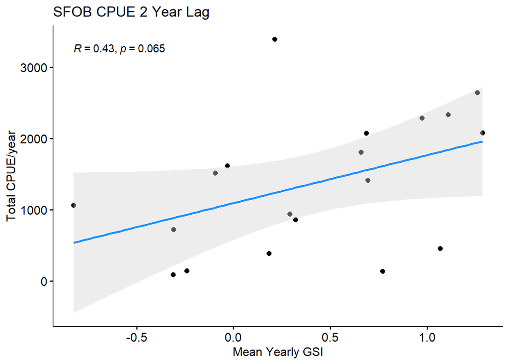

```r
ggscatter(gsi_yr, x = "mean_gsi_lag2", y = "ttl_sum",
          add = "reg.line", conf.int = TRUE,
          cor.coef = TRUE, cor.coeff.args = list(method="pearson"),
          add.params=list(color="dodgerblue", fill="lightgray"),
          xlab = "Mean Yearly GSI", ylab = "Total CPUE/year",
          title = "SFOB CPUE 2 Year Lag")
```

```r
## 3 year lag
lm_cpue_gsi3<-lm(mean_gsi_lag3 ~ ttl_sum, data=gsi_yr)
summary(lm_cpue_gsi3)
```

```
##
## Call:
## lm(formula = mean_gsi_lag3 ~ ttl_sum, data = gsi_yr)
##
## Residuals:
##      Min       1Q   Median       3Q      Max
## -1.02617 -0.43508 -0.03968  0.38423  1.17224
##
## Coefficients:
##               Estimate Std. Error t value Pr(>|t|)
## (Intercept)  5.069e-01  2.822e-01   1.797   0.0913 .
## ttl_sum     -9.042e-05  1.665e-04  -0.543   0.5946
## ---
## Signif. codes:  0 '***' 0.001 '**' 0.01 '*' 0.05 '.' 0.1 ' ' 1
##
## Residual standard error: 0.6324 on 16 degrees of freedom
##   (3 observations deleted due to missingness)
## Multiple R-squared:  0.0181, Adjusted R-squared:  -0.04327
## F-statistic: 0.2949 on 1 and 16 DF,  p-value: 0.5946
```

```r
cor.test(gsi_yr$ttl_sum, gsi_yr$mean_gsi_lag3, method=c("pearson"))
```

```
##
##  Pearson's product-moment correlation
##
## data:  gsi_yr$ttl_sum and gsi_yr$mean_gsi_lag3
## t = -0.54305, df = 16, p-value = 0.5946
## alternative hypothesis: true correlation is not equal to 0
## 95 percent confidence interval:
##  -0.5658579  0.3546148
## sample estimates:
##        cor
## -0.1345276
```

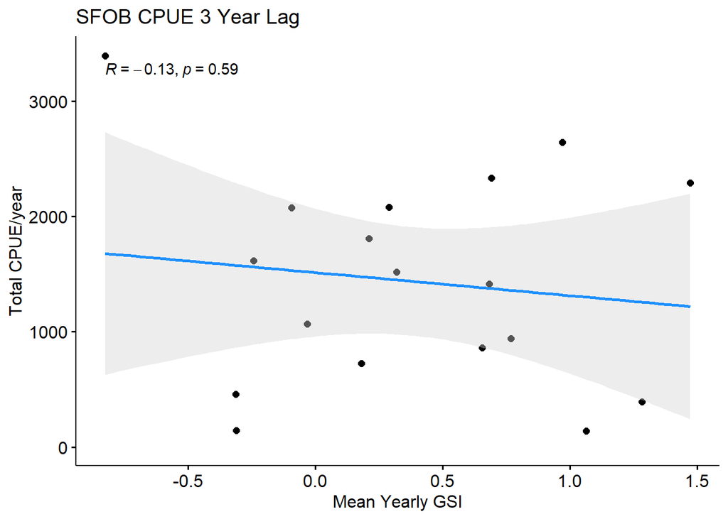

```r
ggscatter(gsi_yr, x = "mean_gsi_lag3", y = "ttl_sum",
          add = "reg.line", conf.int = TRUE,
          cor.coef = TRUE, cor.coeff.args = list(method="pearson"),
          add.params=list(color="dodgerblue", fill="lightgray"),
          xlab = "Mean Yearly GSI", ylab = "Total CPUE/year",
          title = "SFOB CPUE 3 Year Lag")
```

```r
gsi <- read.csv(here::here('C:/Users/stephanie.owen/Documents/tilefish_indicators/data/gulf_stream_index/gsi_sfob.csv'))

gsi_nozero <- filter(gsi, mean_cpue > 0, mean_cpue<15) #removes outlier

gsi.sfob<-mutate(gsi_nozero, pos = ifelse(GSI > 0, 'Northerly', 'Southerly'),
         n.pos = ifelse(GSI > 0, 1, 0))
```

**Regressions and correlations CPUE and GSI - no lag**

```r
#correlations gsi and cpue
lm_gsi<-lm(GSI ~ mean_cpue, data=gsi.sfob)
summary(lm_gsi)
```

```
##
## Call:
## lm(formula = GSI ~ mean_cpue, data = gsi.sfob)
##
## Residuals:
##     Min      1Q  Median      3Q     Max
## -2.1585 -0.4956  0.1054  0.5892  1.3352
##
## Coefficients:
##             Estimate Std. Error t value Pr(>|t|)
## (Intercept)  0.84606    0.07917  10.687  < 2e-16 ***
## mean_cpue   -0.06567    0.02099  -3.129  0.00212 **
## ---
## Signif. codes:  0 '***' 0.001 '**' 0.01 '*' 0.05 '.' 0.1 ' ' 1
##
## Residual standard error: 0.7345 on 144 degrees of freedom
## Multiple R-squared:  0.06366,    Adjusted R-squared:  0.05716
## F-statistic:  9.79 on 1 and 144 DF,  p-value: 0.002124
```

```r
gsi.sfob = gsi.sfob %>%
  mutate(season = case_when(month %in% c(1,2,3) ~ 'winter',
                            month %in% c(4,5,6) ~ 'spring',
                            month %in% c(7,8,9) ~ 'summer',
                            month %in% c(10,11,12) ~ 'fall'))

cor.test(gsi.sfob$mean_cpue, gsi.sfob$GSI, method=c("pearson"))
```

```
##
##  Pearson's product-moment correlation
##
## data:  gsi.sfob$mean_cpue and gsi.sfob$GSI
## t = -3.1289, df = 144, p-value = 0.002124
## alternative hypothesis: true correlation is not equal to 0
## 95 percent confidence interval:
##  -0.39842270 -0.09369611
## sample estimates:
##        cor
## -0.2523042
```

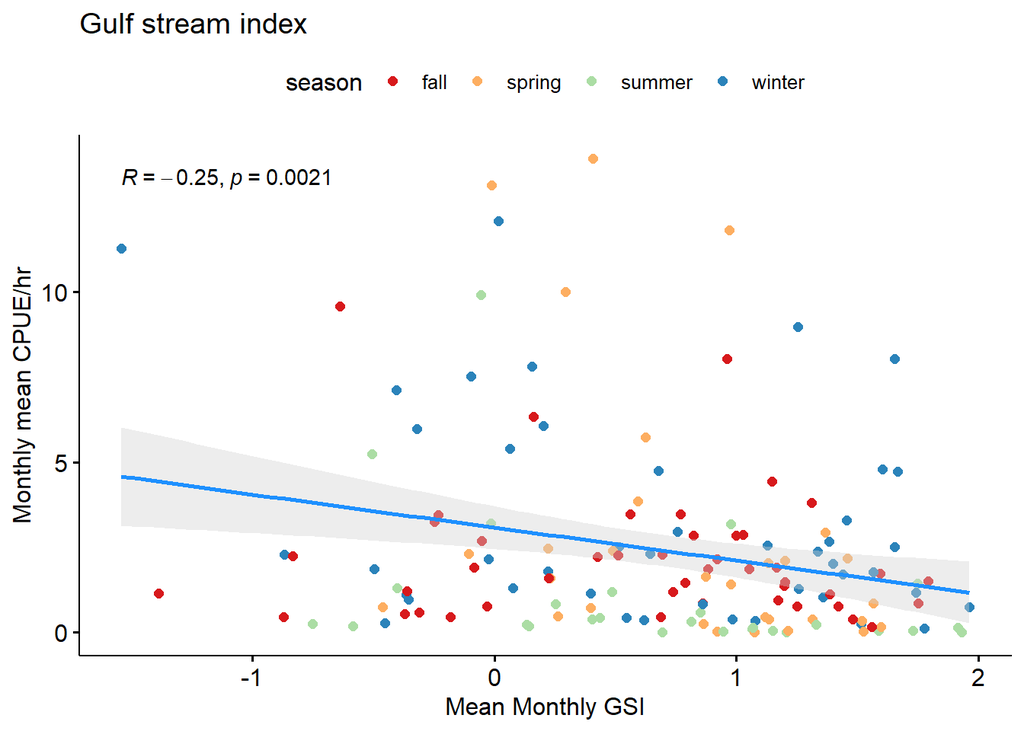

```r
# all months, color coded by season
ggscatter(gsi.sfob, x = "GSI", y = "mean_cpue",
          add = "reg.line", conf.int = TRUE,
          color="season", palette="Spectral",
          cor.coef = TRUE, cor.coeff.args = list(method="pearson"),
          add.params=list(color="dodgerblue", fill="lightgray"),
          xlab = "Mean Monthly GSI", ylab = "Monthly mean CPUE/hr",
          title = "Gulf stream index")
```

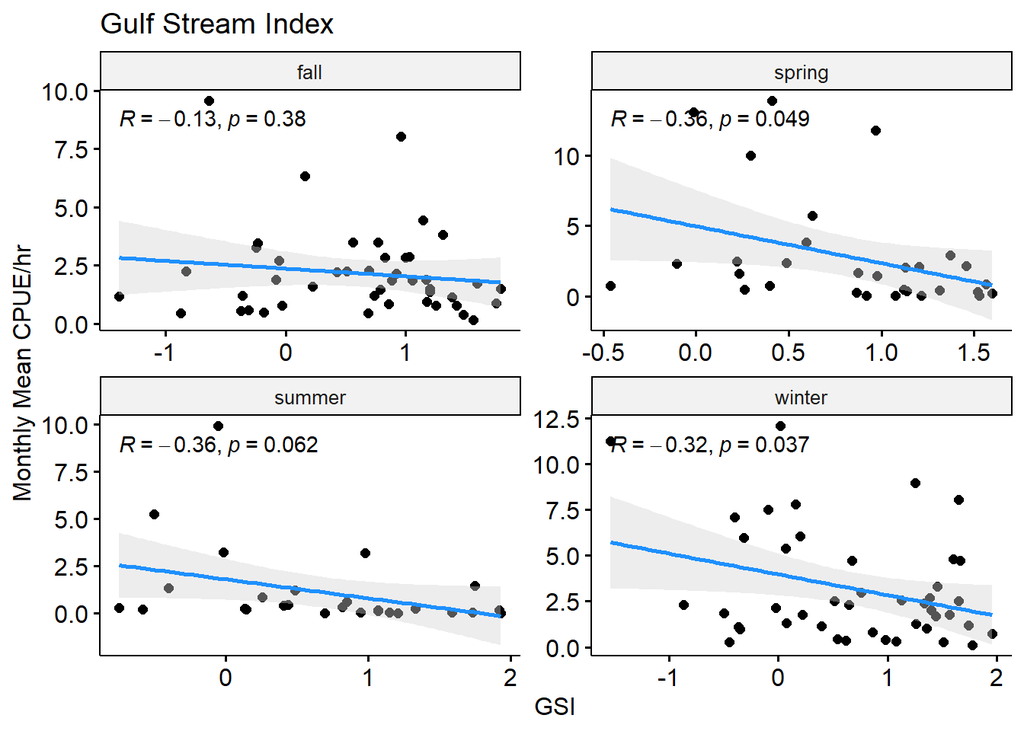

```r
# plot by season
gsi.sfob %>% group_by(year, season) %>%
 ggscatter(x = "GSI", y = "mean_cpue",
          add = "reg.line", conf.int = TRUE,
          cor.coef = TRUE, cor.coeff.args = list(method="pearson"),
          add.params=list(color="dodgerblue", fill="lightgray"),
          xlab = "GSI", ylab = "Monthly Mean CPUE/hr",
          title = "Gulf Stream Index")+
  facet_wrap(~season, scales = 'free')
```

##### Cold pool

Excerpt from New York Bight Fish, Fisheries, and Sand Features: Data Review Volume 1: Literature Synthesis and Gap Analysis:

Natural events are documented for Scup (Morse 1978; Smith and Norcross 1968), Bluefish (Slater et al. 2007), and Northern Puffer (Wicklund 1970) in the MAB and NYB as a result of upwelling of cold bottom water, and for Golden Tilefish on the OCS from eastward flow of the Cold Pool (Fisher et al. 2014). Such events are difficult to detect and quantify because they are episodic, because they could happen in winter when there are few observers, or because they leave dead animals on the bottom instead of floating (Fisher et al.2014) so that they are only detected incidentally by trawler (e.g., Woodhead (1964)).

Cold pool extent:

Positive values == Larger Negative values == Smaller

**Cold pool extent Regressions - No lag**

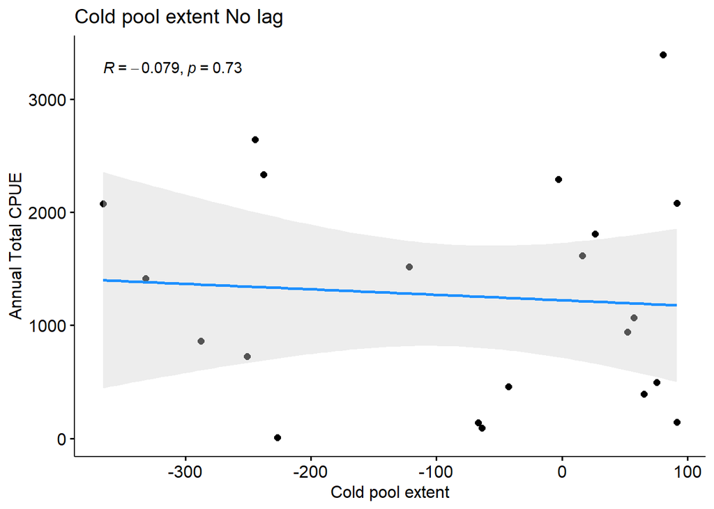

```r
## cold pool extent; yearly value, so no by season

library(ecodata)
# Pull cold pool data
cp <- ecodata::cold_pool
# Selecting just the extent
cp.ex <- cp %>% filter(Time %in% c(1994:2020),
              Var == 'extent_index') %>%
          mutate(ext = Value,
              year = as.numeric(Time))

# Join with sfob yearly total cpue
cp.sfob <- dplyr::full_join(sfob_yr, cp.ex, by = join_by(year)) %>%
  dplyr::select(year, ttl_sum, ext) %>%
  filter(year %in% c(1998:2020))
cp.sfob <- cp.sfob[-c(20:21),] #remove outliers

cp.sfob %>%
  ggscatter(x = 'ext', y = 'ttl_sum',
            add = "reg.line", conf.int = TRUE,
            cor.coef = TRUE, cor.coeff.args = list(method="pearson"),
            add.params=list(color="dodgerblue", fill="lightgray"),
            xlab = "Cold pool extent", ylab = "Annual Total CPUE",
            title="Cold pool extent No lag")
```

**Cold pool persistence Regression - No lag**

Persistence Index: From tech doc: Model_PI measures the duration of the Cold Pool and is estimated using the month when bottom temperature rises above 10C after the Cold Pool is formed each year

Positive values == Longer Negative values == Shorter

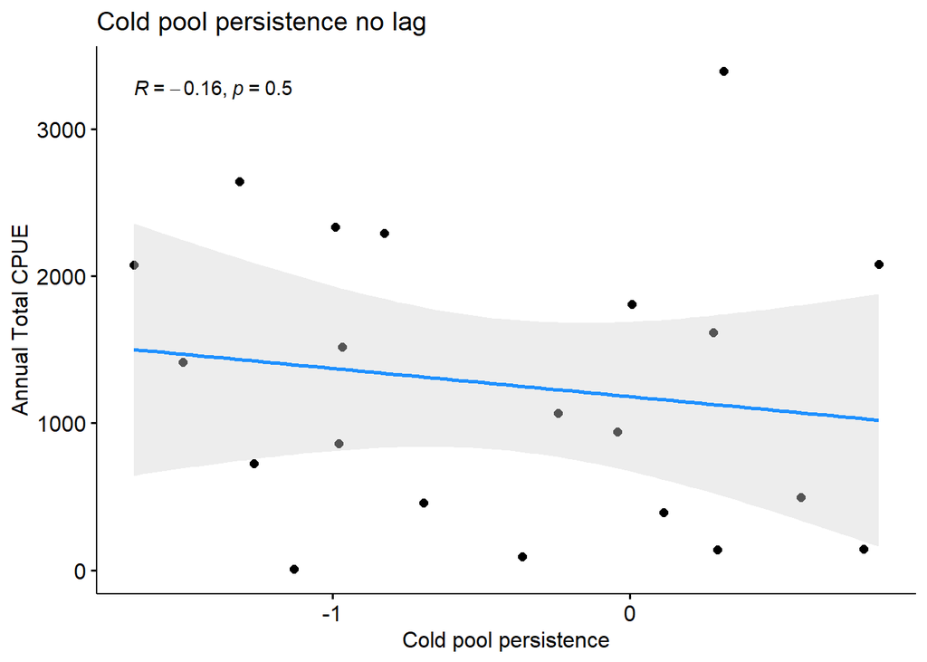

```r
cp.pers <- cp %>% filter(Time %in% c(1994:2020),
              Var == 'persistence_index') %>%
  mutate(pers = Value,
         year = as.numeric(Time))

cp.sfob <- dplyr::full_join(sfob_yr, cp.pers, by = join_by(year)) %>%
  dplyr::select(year, ttl_sum, pers) %>%
  filter(year %in% c(1998:2020))
cp.sfob <- cp.sfob[-c(20:21),] #remove outliers

cp.sfob %>%
  ggscatter(x = 'pers', y = 'ttl_sum',
            add = "reg.line", conf.int = TRUE,
            cor.coef = TRUE, cor.coeff.args = list(method="pearson"),
            add.params=list(color="dodgerblue", fill="lightgray"),
            xlab = "Cold pool persistence", ylab = "Annual Total CPUE",
            title="Cold pool persistence no lag")
```

**Cold pool index Regression - no lag**

Cold pool index:

From tech doc: The Model_SEI is estimated by the number of cells where bottom temperature remains below 10C for at least 2 months between June and September.

Positive values == colder Negative values == warmer

Result: Linear positive trend is weak and non-signficant.

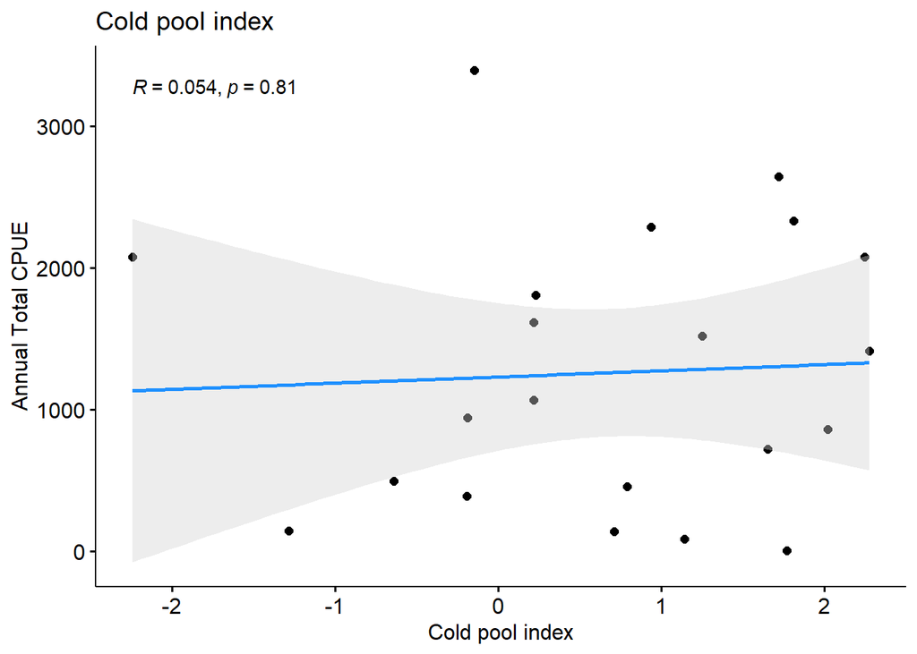

```r
cpi <- cp %>% filter(Time %in% c(1994:2020),
              Var == 'cold_pool_index') %>%
  mutate(cpi = Value,
         year = as.numeric(Time))

cpi <- cpi %>%
  mutate(cpi_lag3 = lag(cpi,3)) #lag 3 years

cp.sfob <- dplyr::full_join(sfob_yr, cpi, by = join_by(year)) %>%
  dplyr::select(year, ttl_sum, cpi, cpi_lag3) %>%
  filter(year %in% c(1998:2020))
cp.sfob <- cp.sfob[-c(20:21),] #remove outliers

cp.sfob %>%
  ggscatter(x = 'cpi', y = 'ttl_sum',
            add = "reg.line", conf.int = TRUE,
            cor.coef = TRUE, cor.coeff.args = list(method="pearson"),
            add.params=list(color="dodgerblue", fill="lightgray"),
            xlab = "Cold pool index", ylab = "Annual Total CPUE",
            title="Cold pool index")
```

#### Food availablity

Larval tilefish eat zooplankton, likely calanus.

##### Microplankton

```r
# microplankton
micro<-read.csv(here::here('data/phyto_size_class/microplankton_ts_gtf_strata.csv'))
```

##### Microplankton analysis

```r
# filter sfob.env
sfob <- sfob.env %>% filter(depth > 50, cpue_hr > 0, cpue_hr<15) %>%
  group_by(year,month) %>%
  summarise(mean_cpue = mean(cpue_hr))

# Join with sf/ob data
micro.sfob <- dplyr::full_join(micro, sfob, by = join_by(year, month)) %>%
  dplyr::select(year, month, mean_cpue, mean_micro, weighted_mean_micro) %>%
  tidyr::drop_na()
```

**Micro Regressions and correlation - no lag**

```r
# Correlation and plot
lm_micro<-lm(weighted_mean_micro ~ mean_cpue, data=micro.sfob)
summary(lm_micro)
```

```
##
## Call:
## lm(formula = weighted_mean_micro ~ mean_cpue, data = micro.sfob)
##
## Residuals:
##      Min       1Q   Median       3Q      Max
## -0.36535 -0.12087 -0.01128  0.07238  0.78516
##
## Coefficients:
##             Estimate Std. Error t value Pr(>|t|)
## (Intercept) 0.225797   0.025049   9.014 4.97e-16 ***
## mean_cpue   0.026195   0.006092   4.300 2.92e-05 ***
## ---
## Signif. codes:  0 '***' 0.001 '**' 0.01 '*' 0.05 '.' 0.1 ' ' 1
##
## Residual standard error: 0.1651 on 164 degrees of freedom
## Multiple R-squared:  0.1013, Adjusted R-squared:  0.09584
## F-statistic: 18.49 on 1 and 164 DF,  p-value: 2.925e-05
```

```r
micro.sfob = micro.sfob %>%
  mutate(season = case_when(month %in% c(1,2,3) ~ 'winter',
                            month %in% c(4,5,6) ~ 'spring',
                            month %in% c(7,8,9) ~ 'summer',
                            month %in% c(10,11,12) ~ 'fall'))

cor.test(micro.sfob$mean_cpue, micro.sfob$weighted_mean_micro, method=c("pearson"))
```

```
##
##  Pearson's product-moment correlation
##
## data:  micro.sfob$mean_cpue and micro.sfob$weighted_mean_micro
## t = 4.2999, df = 164, p-value = 2.925e-05
## alternative hypothesis: true correlation is not equal to 0
## 95 percent confidence interval:
##  0.1744365 0.4488596
## sample estimates:
##       cor
## 0.3183006
```

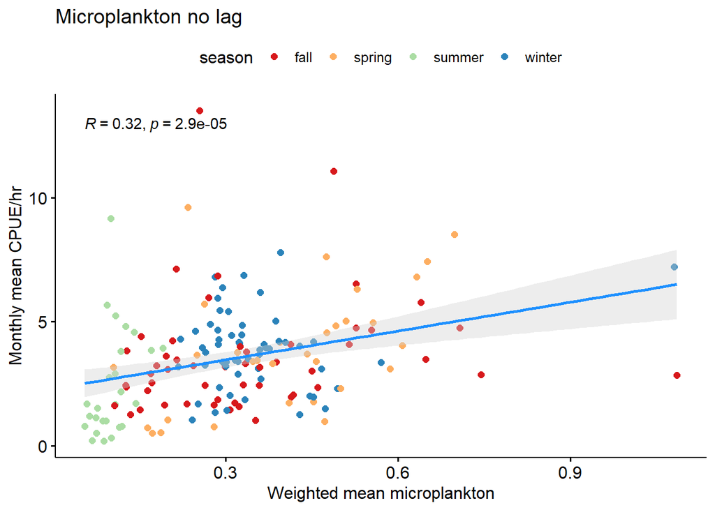

```r
#all months, color coded by season
ggscatter(micro.sfob, x = "weighted_mean_micro", y = "mean_cpue",
          add = "reg.line", conf.int = TRUE,
          color="season", palette="Spectral",
          cor.coef = TRUE, cor.coeff.args = list(method="pearson"),
          add.params=list(color="dodgerblue", fill="lightgray"),
          xlab = "Weighted mean microplankton", ylab = "Monthly mean CPUE/hr",
          title = "Microplankton no lag")
```

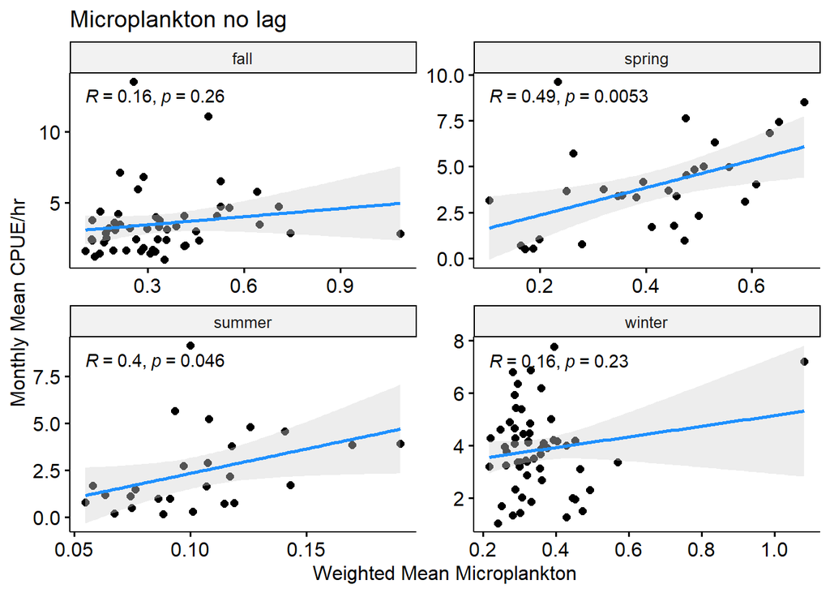

```r
# by season
micro.sfob %>% group_by(year, season) %>%
 ggscatter(x = "weighted_mean_micro", y = "mean_cpue",
          add = "reg.line", conf.int = TRUE,
          cor.coef = TRUE, cor.coeff.args = list(method="pearson"),
          add.params=list(color="dodgerblue", fill="lightgray"),
          xlab = "Weighted Mean Microplankton", ylab = "Monthly Mean CPUE/hr",
          title = "Microplankton no lag")+
  facet_wrap(~season, scales = 'free')
```

##### Chlorophyll-A

```r
# CHL-A
chl<-read.csv(here::here('data/chl/chl_ts_gtf_strata.csv'))
```

##### Chlorophyll-A analysis

```r
# filter sfob.env
sfob <- sfob.env %>% filter(depth > 50, cpue_hr > 0, cpue_hr<15) %>%
  group_by(year,month) %>%
  summarise(mean_cpue = mean(cpue_hr))

# Join with sf/ob data
chl.sfob <- dplyr::full_join(chl, sfob, by = join_by(year, month)) %>%
  dplyr::select(year, month, mean_cpue, mean_chl, weighted_mean_chl) %>%
  tidyr::drop_na()
```

**CHL-a Regression and correlation - no lag**

```r
lm_chl<-lm(weighted_mean_chl ~ mean_cpue, data=chl.sfob)
summary(lm_chl)
```

```
##
## Call:
## lm(formula = weighted_mean_chl ~ mean_cpue, data = chl.sfob)
##
## Residuals:
##      Min       1Q   Median       3Q      Max
## -0.48876 -0.14249 -0.02789  0.11340  1.16872
##
## Coefficients:
##             Estimate Std. Error t value Pr(>|t|)
## (Intercept) 0.560871   0.035029  16.012  < 2e-16 ***
## mean_cpue   0.032932   0.008519   3.866 0.000159 ***
## ---
## Signif. codes:  0 '***' 0.001 '**' 0.01 '*' 0.05 '.' 0.1 ' ' 1
##
## Residual standard error: 0.2309 on 164 degrees of freedom
## Multiple R-squared:  0.08351,    Adjusted R-squared:  0.07792
## F-statistic: 14.94 on 1 and 164 DF,  p-value: 0.0001594
```

```r
chl.sfob = chl.sfob %>%
  mutate(season = case_when(month %in% c(1,2,3) ~ 'winter',
                            month %in% c(4,5,6) ~ 'spring',
                            month %in% c(7,8,9) ~ 'summer',
                            month %in% c(10,11,12) ~ 'fall'))

cor.test(chl.sfob$mean_cpue, chl.sfob$weighted_mean_chl, method=c("pearson"))
```

```
##
##  Pearson's product-moment correlation
##
## data:  chl.sfob$mean_cpue and chl.sfob$weighted_mean_chl
## t = 3.8657, df = 164, p-value = 0.0001594
## alternative hypothesis: true correlation is not equal to 0
## 95 percent confidence interval:
##  0.1429489 0.4226937
## sample estimates:
##       cor
## 0.2889781
```

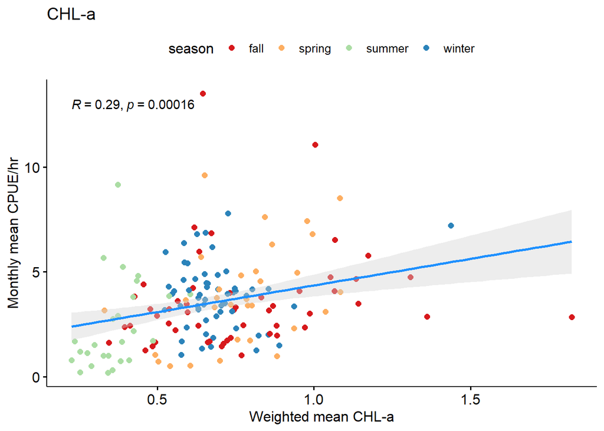

```r
#all seasons - color coded
ggscatter(chl.sfob, x = "weighted_mean_chl", y = "mean_cpue",
          add = "reg.line", conf.int = TRUE,
          color="season", palette="Spectral",
          cor.coef = TRUE, cor.coeff.args = list(method="pearson"),
          add.params=list(color="dodgerblue", fill="lightgray"),
          xlab = "Weighted mean CHL-a", ylab = "Monthly mean CPUE/hr",
          title = "CHL-a")
```

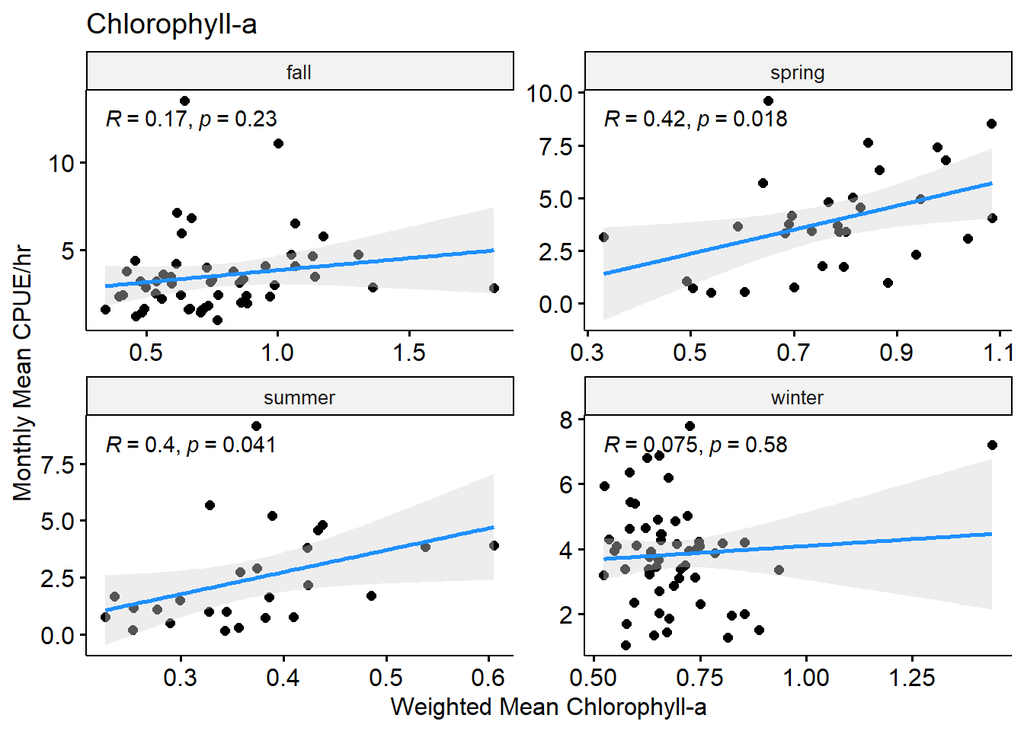

```r
#by season
chl.sfob %>% group_by(year, season) %>%
 ggscatter(x = "weighted_mean_chl", y = "mean_cpue",
          add = "reg.line", conf.int = TRUE,
          cor.coef = TRUE, cor.coeff.args = list(method="pearson"),
          add.params=list(color="dodgerblue", fill="lightgray"),
          xlab = "Weighted Mean Chlorophyll-a", ylab = "Monthly Mean CPUE/hr",
          title = "Chlorophyll-a")+
  facet_wrap(~season, scales = 'free')
```